# MEDL_midterm

**Deep Learning for Mechanical Engineering**  
**Midterm Exam**  
**May 7th 2020, 3:15 PM to 5 PM (105 mins)**

TA: Kangsan Lee and Namjeong Lee  
Instructor: Prof. Seungchul Lee  
http://iai.postech.ac.kr/  
Industrial AI Lab at POSTECH

- I am not able to answer questions due to an online exam. I suggest you to sove the problems based on what you have here. I will try to be fair (or reasonable) on grading if any issues on problems are found afterwards.
- For your handwritten solution, scan or take a picture of them.
- For your code, only .ipynb file will be graded.
  - Please write your NAME and student ID on your .ipynb files. ex) KangsanLee_20202467_midterm.ipynb
- Please compress all the files to make a single .zip file
  - Please write your NAME and student ID on your .zip files. ex) NamjeongLee_20202467_midterm.zip
  - Submit it to LMS
- Do not submit a printed version of your code. It will not be graded.
- Please submit your answer sheet on time. No late submission will be allowed.

**Data Download Link**

- [Download data](https://www.dropbox.com/sh/rdxukph9b46w7jz/AACsB2nuYMjJXnnDUe-jpOupa?dl=1)

# Problem 1

Consider the optimization problem whose loss function is defined as follows,

$$\ell = (x_1-3x_2)^2 +(x_2+x_3)^2+(x_1-5)^2+(x_3+3)^2$$

We want to minimize our loss.

(1) [2pt, hand-written] Find $x^{*} = \text{argmin}\space\ell$ by an analytic approach. After defining your equation, you can use either python or a calculator to compute.

(2) [2pt, hand-written] Write the quadratic form of the above equation. (i.e. $\ell = \frac{1}{2}X^THX+g^TX$)

(3) [2pt, hand-written] Write the gradient of the quadratic equation in (2). And write a gradient descent algorithm as well.

(4) [5pt] Write your code to solve the optimization problem by the gradient descent algorithm. Iterate your gradient descent algorithm until error reaches to less than 0.01. Set the learning rate as 0.001

```python
# Your code here
```

# Problem 2

[hand-written] The below is the objective function of linear regression with a regularization term.

$$ \min\limits_\theta {\lVert A\theta - y \rVert}_2^2 + \lambda \lVert \theta \rVert_2^2$$

(a) [5pt] Prove

$$\theta^* = \left( A^T A + \lambda I \right)^{-1} A^T y$$

(b) [5pt] Explain why $\,\theta^* = \left( A^T A + \lambda I \right)^{-1} A^T y \,$ results in a regularization effect.

$\;\;\,$ (Hint: think about a value of $\theta$ for large $\lambda$)

# Problem 3

[hand-written]

(1) [2pt] What are the advantages (or characteristics) of the logistic regression compared to the perceptron?

(2) [2pt] What is the advantage of having big data?

(3) [2pt] Then why do we divide data into training set, and validation (testing) set?

(4) [2pt] Suggest possible approaches to avoid overfitting.

# Problem 4

[hand-written] Suppose a multi-layer perceptron which has an input layer with 10 neurons, a hidden layer with 50 neurons, and an output layer with 3 neurons. Non-linear activation function for every neurons are ReLU. Write your answer to the following questions.

(1) [1pt] Size of input $X$?

(2) [1pt] Size of weights and biases ($W_h, b_h$) for the hidden layer?

(3) [1pt] Size of weights and biases ($W_o, b_o$) for the output layer?

(4) [1pt] Size of output $Y$?

(5) [2pt] Write output $Y$ as a function of $X, W_h, b_h, W_o, b_o$ (Use ReLU as a non-linear activation function)

# Problem 5

**PCA (Principal Component Analysis)**

- PCA is one of the oldest and most widely used dimensionality reduction algorithms. Its idea is to reduce the dimensionality of a dataset, while preserving as much 'variability' as possible. (but you don't need to fully understand the PCA algorithm for this problem.)

Actually, autoencoder is very similar to the PCA algorithm in terms of 'dimension reduction'. So, in this problem, we are going to build up PCA with autoencoder. While PCA is a linear dimension reduction method, the autoencoder has non-linear activation functions. Therefore, autoencoder without non-linear activation functions can be considered as PCA.

Now, we have 3D data. Run the below cell to load and 3D plot them.

**Data Download Link** (same)

- [Download data](https://www.dropbox.com/sh/rdxukph9b46w7jz/AACsB2nuYMjJXnnDUe-jpOupa?dl=1)

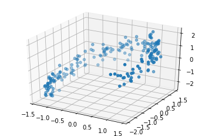

```python
import numpy as np
import matplotlib.pyplot as plt
from mpl_toolkits.mplot3d import Axes3D

data = np.load('./data_files/pca_autoencoder.npy')
fig = plt.figure()
ax = fig.add_subplot(111, projection = '3d')
ax.scatter(data[:,0], data[:,1], data[:,2])
plt.show()

X_train, X_test = data[:100], data[100:]
```

PCA result in 2D is shown as follows.

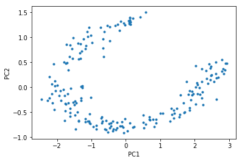

```python
from sklearn.decomposition import PCA

pca = PCA(n_components=2)
pca.fit(data)
result = pca.transform(data)
plt.figure()
plt.plot(result[:,0],result[:,1],'.')
plt.xlabel('PC1')
plt.ylabel('PC2')
plt.show()
```

(1) [6pt] Design your linear autoencoder model using `TensorFlow`. (freely design your own network structure)

```python
import tensorflow as tf

# Your code here
```

(2) [3pt] After training your model, plot the data on latent space. (below figure is one of the possible plots)

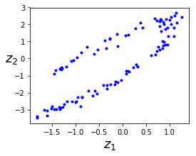

```python
# Your code here
```

## Problem 6

**Rotating Machinery Diagnosis with Logistic Regression**

Mechanical systems are always vibrating when operating. So, vibration analysis is one of the most popular and conventional ways to diagnose the mechanical system. In this problem, we are going to use the logistic regression algorithm to identify abnormality of a mechanical system.

**Data information**

- File format: npy
- Information: signal, label
- Sampling rate: 12,800 Hz
- File length (time): 0.78 sec
- Labels based on one-hot encoding
  - A (Normal): [1,0]
  - B (Abnormal): [0,1]

**Data Download Link** (same)

- [Download data](https://www.dropbox.com/sh/rdxukph9b46w7jz/AACsB2nuYMjJXnnDUe-jpOupa?dl=1)

```python
import numpy as np
import matplotlib.pyplot as plt
import tensorflow as tf
import IPython.display as ipd
import scipy.stats
import scipy
%matplotlib inline

# data load
data = {
    'signal': np.load('./data_files/signal.npy'),
    'label': np.load('./data_files/label.npy')
}

idx_A = []
idx_B = []
for i in range(len(data['label'])):
    if data['label'][i] == False:
        idx_A.append(i)
    else:
        idx_B.append(i)

# one-hot encoding
data['label'] = tf.keras.utils.to_categorical(data['label'])
```

Run the below cells to hear the sound of A and B.

```python
fs = 12800
signal_A = data['signal'][np.random.choice(idx_A),:]
ipd.Audio(signal_A, rate = fs)
```

[interactive chart not shown]

```python
signal_B = data['signal'][np.random.choice(idx_B),:]
ipd.Audio(signal_B, rate = fs)
```

[interactive chart not shown]

(1) [2pt] Plot 2 randomly selected vibration signals.

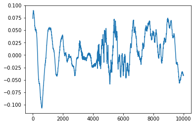

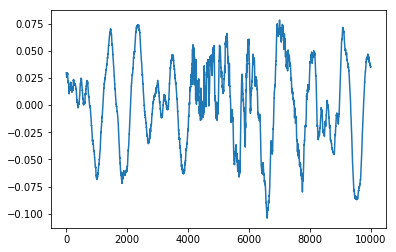

```python
# Your code here
```

Now, we need to extract features from the raw signal.

- Use the following statistical features
  - peak, rms, kurtosis, crest factor, impulse factor, shape factor, skewness, smr, peak-peak

The equations are as follows:

$$\begin{align*} \text{Peak Value } &= \max_{n = 1, \dots, N} x_n \\ \\ \text{RMS } &= \sqrt{\frac{1}{N}\sum_{n=1}^N x_n^2} \\ \\ \text{Kurtosis } &= \frac{\frac{1}{N}\sum_{n=1}^N (x_n-\bar{x})^4}{\text{Var}^2} \\ \\ \text{Var } &= \frac{1}{N}\sum_{n=1}^N (x_n-\bar{x})^2 \\\\ \text{Crest Factor } &= \frac{\text{Peak}}{\text{RMS}}\\\\ \text{Impulse Factor } &= \frac{\text{Peak}}{\text{Mean}} \\ \\ \text{Mean } &= \frac{1}{N}\sum_{n=1}^N \lvert x_n \rvert \\\\ \text{Shape Factor } &= \frac{\text{RMS}}{\text{Mean}}\\\\ \text{Skewness } &= \frac{\frac{1}{N}\sum_{n=1}^N(x_n-\bar{x})^3}{\text{Var}^{3/2}}\\\\ \text{SMR } &= \left(\frac{1}{N}\sum_{n=1}^N\sqrt{x_n} \right)^2 \\\\ \text{Peak-Peak Value } &= \max_{n = 1, \dots, N} x_n-\min_{n = 1, \dots, N} x_n \end{align*}$$$$x_i: \text{signal data}$$

The function for feature extraction is already ready for you. The function input and output are data $x$ and horizontally stacked feature vector, respectively.

```python
def extfeat(x):
    fvector = []

    # time domain feature
    peak = np.max(np.abs(x))
    fvector.append(peak)

    rms = np.sqrt(np.mean(x**2))
    fvector.append(rms)

    kurtosis = scipy.stats.kurtosis(x)
    fvector.append(kurtosis)

    crest_factor = fvector[0]/fvector[1]
    fvector.append(crest_factor)

    impulse_factor = fvector[0]/(np.sum(np.abs(x))/len(x))
    fvector.append(impulse_factor)

    shape_factor = fvector[1]/(np.sum(np.abs(x))/len(x))
    fvector.append(shape_factor)

    skewness = scipy.stats.skew(x)
    fvector.append(skewness)

    smr = (np.sum(np.sqrt(np.abs(x)))/len(x))**2
    fvector.append(smr)

    pp = np.max(x) - np.min(x)
    fvector.append(pp)

    return fvector

feature_name = ['Peak', 'RMS', 'Kurtosis', 'Crest Factor', 'Impulse Factor','Shape Factor','Skewness','SMR', 'Peak-Peak']
```

(2) [2pt] Print out features of a randomly selected signal. You can use the above `extfeat` function.

```python
# Your code here
```

(3) [2pt] Split train and test data with your own separating ratio.

```python
# Your code here
```

(4) [6pt] Design your logistic regression model using `TensorFlow` and train it. Record the loss during traing.

```python
# Your code here
```

(5) [2pt] Print out learned $\omega$ and plot the loss over iterations.

```python
# Your code here
```

(6) [4pt] Compute test accuracy. You should use learned $\omega$ to predict labels for unseen test data.

Note: test accuracy would be somewhat low (around 80%).

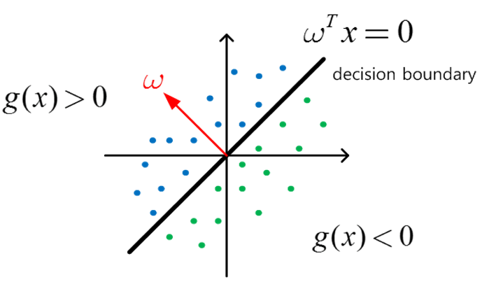

```python
# Your code here
```